# Proj5-1

Sam Hurenkamp & Matias Becker Burgos

2024-02-22

## Research Question

Influenza A viruses (IAVs) are zoonotic pathogens that can infect a broad range of animals from birds to pigs and humans. Most of these species have wild birds as their natural hosts. IAVs are usually adapted and relatively restricted to a single host but occasionally the virus can jump and adapt to a new host species. The interspecies transmission requires that IAVs adapt to the new host and the whole process is facilitated by their high mutation rates. This can result in epidemics and pandemics with severe consequences for both human and animal life. Given our poor understanding of the ost-adaptation process of the virus, which can be a major factor for such epidemics and pandemics, it is very hard to predict the type of the virus that will cause the coming outbreaks. The hemagglutinin protein plays a crucial part in defining the adaptation of the virus to different hosts since it binds to the receptor providing the entry into host cells. The avian strains of the IAVs are known to prefer a receptor with α2,3-sialic acid linkages while the human strains prefer a receptor with α2,6-sialic acid linkages. However, other proteins subunits have also previously been shown to play a role in the adaptation of IAVs to different hosts.

## Data Exploration

#### Description of the dataset

The data is decision tables made from the multiple sequence alignments of the proteins. The decision classes are either Avian or Human indicating the hosts in which the viruses were found.

```r
df <- read.csv("Project5.csv", sep = "\t")
df.head <- head(df, 10)
kbl(df.head) %>%
  kable_styling(bootstrap_options = c("striped", "hover"), full_width = F, position = "center")
```

| id | P1 | P2 | P3 | P4 | P5 | P6 | P7 | P8 | P9 | P10 | P11 | P12 | P13 | P14 | P15 | P16 | P17 | P18 | P19 | P20 | P21 | P22 | P23 | P24 | P25 | P26 | P27 | P28 | P29 | … |
| --- | --- | --- | --- | --- | --- | --- | --- | --- | --- | --- | --- | --- | --- | --- | --- | --- | --- | --- | --- | --- | --- | --- | --- | --- | --- | --- | --- | --- | --- | --- |
| >AIJ10997*A/duck/Shanghai/SH1/2013*2013/04/26*PB2*H3N2*China*Avian | ? | ? | ? | ? | M | E | R | I | K | E | L | R | D | L | M | S | Q | S | R | TRUE | R | E | I | L | TRUE | K | TRUE | TRUE | V | … |
| >AHC61726*A/Peru/PER317/2010*2010/10/25*PB2*H3N2*Peru*Human | ? | ? | ? | ? | M | E | R | I | K | E | L | R | N | L | M | S | Q | S | R | TRUE | R | E | I | L | TRUE | K | TRUE | TRUE | V | … |
| >AFN66839*A/duck/Guangdong/W12/2011*2011/12/22*PB2*H3N2*China*Avian | ? | ? | ? | ? | M | E | R | I | K | E | L | R | E | L | M | S | Q | S | R | TRUE | R | E | I | L | TRUE | K | TRUE | TRUE | V | … |
| >ABG37306*A/New York/671/1995*1995/01/06*PB2*H3N2*USA*Human | ? | ? | ? | ? | M | E | R | I | K | E | L | R | N | L | M | S | Q | S | R | TRUE | R | E | I | L | TRUE | K | TRUE | TRUE | V | … |
| >ACF25011*A/mallard/Minnesota/68/1999*1999//*PB2*H3N2*USA*Avian | ? | ? | ? | ? | M | E | R | I | K | E | L | R | D | L | M | S | Q | S | R | TRUE | R | E | I | L | TRUE | K | TRUE | TRUE | V | … |
| >ACN43024*A/Ohio/UR07-0035/2008*2008/02/18*PB2*H3N2*USA*Human | ? | ? | ? | ? | M | E | R | I | K | E | L | R | N | L | M | S | Q | S | R | TRUE | R | E | I | L | TRUE | K | TRUE | TRUE | V | … |
| >AHN00668*A/blue-winged teal/Wisconsin/331/1981*1981//*PB2*H3N2*USA*Avian | ? | ? | ? | ? | M | E | R | I | K | E | L | R | D | L | M | S | Q | S | R | TRUE | R | E | I | L | TRUE | K | TRUE | TRUE | V | … |
| >AFG72943*A/Netherlands/69/2009*2009/01/12*PB2*H3N2*Netherlands*Human | ? | ? | ? | ? | M | E | R | I | K | E | L | R | N | L | M | S | Q | S | R | TRUE | R | E | I | L | TRUE | K | TRUE | TRUE | V | … |
| >AHN04334*A/duck/Wisconsin/1159/1978*1978//*PB2*H3N2*USA*Avian | ? | ? | ? | ? | M | E | R | I | K | E | L | R | D | L | M | S | Q | S | R | TRUE | R | E | I | L | TRUE | K | TRUE | TRUE | V | … |
| >ACO94792*A/Kentucky/UR07-0149/2008*2008/03/10*PB2*H3N2*USA*Human | ? | ? | ? | ? | M | E | R | I | K | E | L | R | N | L | M | S | Q | S | R | TRUE | R | E | I | L | TRUE | K | TRUE | TRUE | V | … |

```r
dim(df)
```

```
## [1] 272 778
```

```r
# check target labels
target_class_labels <- unique(df$Host)
target_class_labels
```

```
## [1] "Avian" "Human"
```

```r
# initial read shows that some T AAs were misread as "TRUE" and F as "FALSE". Let's fix that.
df[] <- lapply(df, function(x) ifelse(x == "TRUE", "T", x))
df[] <- lapply(df, function(x) ifelse(x == "FALSE", "F", x))
df.head <- head(df, 10)
kbl(df.head) %>%
  kable_styling(bootstrap_options = c("striped", "hover"), full_width = F, position = "center")
```

| id | P1 | P2 | P3 | P4 | P5 | P6 | P7 | P8 | P9 | P10 | P11 | P12 | P13 | P14 | P15 | P16 | P17 | P18 | P19 | P20 | P21 | P22 | P23 | P24 | P25 | P26 | P27 | P28 | P29 | … |
| --- | --- | --- | --- | --- | --- | --- | --- | --- | --- | --- | --- | --- | --- | --- | --- | --- | --- | --- | --- | --- | --- | --- | --- | --- | --- | --- | --- | --- | --- | --- |
| >AIJ10997*A/duck/Shanghai/SH1/2013*2013/04/26*PB2*H3N2*China*Avian | ? | ? | ? | ? | M | E | R | I | K | E | L | R | D | L | M | S | Q | S | R | T | R | E | I | L | T | K | T | T | V | … |
| >AHC61726*A/Peru/PER317/2010*2010/10/25*PB2*H3N2*Peru*Human | ? | ? | ? | ? | M | E | R | I | K | E | L | R | N | L | M | S | Q | S | R | T | R | E | I | L | T | K | T | T | V | … |
| >AFN66839*A/duck/Guangdong/W12/2011*2011/12/22*PB2*H3N2*China*Avian | ? | ? | ? | ? | M | E | R | I | K | E | L | R | E | L | M | S | Q | S | R | T | R | E | I | L | T | K | T | T | V | … |
| >ABG37306*A/New York/671/1995*1995/01/06*PB2*H3N2*USA*Human | ? | ? | ? | ? | M | E | R | I | K | E | L | R | N | L | M | S | Q | S | R | T | R | E | I | L | T | K | T | T | V | … |
| >ACF25011*A/mallard/Minnesota/68/1999*1999//*PB2*H3N2*USA*Avian | ? | ? | ? | ? | M | E | R | I | K | E | L | R | D | L | M | S | Q | S | R | T | R | E | I | L | T | K | T | T | V | … |
| >ACN43024*A/Ohio/UR07-0035/2008*2008/02/18*PB2*H3N2*USA*Human | ? | ? | ? | ? | M | E | R | I | K | E | L | R | N | L | M | S | Q | S | R | T | R | E | I | L | T | K | T | T | V | … |
| >AHN00668*A/blue-winged teal/Wisconsin/331/1981*1981//*PB2*H3N2*USA*Avian | ? | ? | ? | ? | M | E | R | I | K | E | L | R | D | L | M | S | Q | S | R | T | R | E | I | L | T | K | T | T | V | … |
| >AFG72943*A/Netherlands/69/2009*2009/01/12*PB2*H3N2*Netherlands*Human | ? | ? | ? | ? | M | E | R | I | K | E | L | R | N | L | M | S | Q | S | R | T | R | E | I | L | T | K | T | T | V | … |
| >AHN04334*A/duck/Wisconsin/1159/1978*1978//*PB2*H3N2*USA*Avian | ? | ? | ? | ? | M | E | R | I | K | E | L | R | D | L | M | S | Q | S | R | T | R | E | I | L | T | K | T | T | V | … |
| >ACO94792*A/Kentucky/UR07-0149/2008*2008/03/10*PB2*H3N2*USA*Human | ? | ? | ? | ? | M | E | R | I | K | E | L | R | N | L | M | S | Q | S | R | T | R | E | I | L | T | K | T | T | V | … |

```r
# Remove null (gap) columns
df <- df %>%
  select(where(~ !all(. == "?"))) # regex - Select only columns where all values are not "?"
df.head <- head(df, 10)
kbl(df.head) %>%
  kable_styling(bootstrap_options = c("striped", "hover"), full_width = F, position = "center")
```

| id | P5 | P6 | P7 | P8 | P9 | P10 | P11 | P12 | P13 | P14 | P15 | P16 | P17 | P18 | P19 | P20 | P21 | P22 | P23 | P24 | P25 | P26 | P27 | P28 | P29 | P30 | P31 | P32 | P33 | … |
| --- | --- | --- | --- | --- | --- | --- | --- | --- | --- | --- | --- | --- | --- | --- | --- | --- | --- | --- | --- | --- | --- | --- | --- | --- | --- | --- | --- | --- | --- | --- |
| >AIJ10997*A/duck/Shanghai/SH1/2013*2013/04/26*PB2*H3N2*China*Avian | M | E | R | I | K | E | L | R | D | L | M | S | Q | S | R | T | R | E | I | L | T | K | T | T | V | D | H | M | A | … |
| >AHC61726*A/Peru/PER317/2010*2010/10/25*PB2*H3N2*Peru*Human | M | E | R | I | K | E | L | R | N | L | M | S | Q | S | R | T | R | E | I | L | T | K | T | T | V | D | H | M | A | … |
| >AFN66839*A/duck/Guangdong/W12/2011*2011/12/22*PB2*H3N2*China*Avian | M | E | R | I | K | E | L | R | E | L | M | S | Q | S | R | T | R | E | I | L | T | K | T | T | V | D | H | M | A | … |
| >ABG37306*A/New York/671/1995*1995/01/06*PB2*H3N2*USA*Human | M | E | R | I | K | E | L | R | N | L | M | S | Q | S | R | T | R | E | I | L | T | K | T | T | V | D | H | M | A | … |
| >ACF25011*A/mallard/Minnesota/68/1999*1999//*PB2*H3N2*USA*Avian | M | E | R | I | K | E | L | R | D | L | M | S | Q | S | R | T | R | E | I | L | T | K | T | T | V | D | H | M | A | … |
| >ACN43024*A/Ohio/UR07-0035/2008*2008/02/18*PB2*H3N2*USA*Human | M | E | R | I | K | E | L | R | N | L | M | S | Q | S | R | T | R | E | I | L | T | K | T | T | V | D | H | M | A | … |
| >AHN00668*A/blue-winged teal/Wisconsin/331/1981*1981//*PB2*H3N2*USA*Avian | M | E | R | I | K | E | L | R | D | L | M | S | Q | S | R | T | R | E | I | L | T | K | T | T | V | D | H | M | A | … |
| >AFG72943*A/Netherlands/69/2009*2009/01/12*PB2*H3N2*Netherlands*Human | M | E | R | I | K | E | L | R | N | L | M | S | Q | S | R | T | R | E | I | L | T | K | T | T | V | D | H | M | A | … |
| >AHN04334*A/duck/Wisconsin/1159/1978*1978//*PB2*H3N2*USA*Avian | M | E | R | I | K | E | L | R | D | L | M | S | Q | S | R | T | R | E | I | L | T | K | T | T | V | D | H | M | A | … |
| >ACO94792*A/Kentucky/UR07-0149/2008*2008/03/10*PB2*H3N2*USA*Human | M | E | R | I | K | E | L | R | N | L | M | S | Q | S | R | T | R | E | I | L | T | K | T | T | V | D | H | M | A | … |

```r
dim(df)
```

```
## [1] 272 769
```

```r
df$P772  # Some values in here, but sparsity is extremely high. Should consider just removing these columns
```

```
##   [1] "?" "?" "?" "?" "?" "?" "?" "?" "?" "?" "?" "?" "?" "?" "?" "?" "?" "?"
##  [19] "?" "?" "?" "?" "?" "?" "?" "?" "?" "?" "?" "?" "?" "?" "?" "?" "?" "?"
##  [37] "?" "?" "?" "?" "?" "?" "?" "?" "?" "?" "?" "?" "?" "?" "?" "?" "?" "?"
##  [55] "?" "?" "?" "?" "?" "?" "?" "?" "?" "?" "?" "?" "?" "?" "?" "?" "?" "?"
##  [73] "?" "?" "?" "?" "?" "?" "?" "?" "?" "Q" "?" "?" "?" "?" "?" "?" "?" "?"
##  [91] "?" "?" "?" "?" "?" "?" "?" "?" "?" "?" "?" "?" "?" "?" "?" "?" "?" "?"
## [109] "?" "?" "?" "?" "?" "?" "?" "?" "?" "?" "?" "?" "?" "?" "?" "?" "?" "?"
## [127] "?" "?" "?" "?" "?" "?" "?" "?" "?" "?" "?" "?" "?" "?" "?" "?" "?" "?"
## [145] "?" "?" "?" "?" "?" "?" "?" "?" "?" "?" "?" "?" "?" "?" "?" "?" "?" "?"
## [163] "?" "?" "?" "?" "?" "?" "?" "?" "?" "?" "?" "?" "?" "?" "?" "?" "?" "?"
## [181] "?" "?" "?" "?" "?" "?" "?" "?" "?" "?" "?" "?" "?" "?" "?" "?" "?" "?"
## [199] "?" "?" "?" "?" "?" "?" "?" "?" "?" "?" "?" "?" "?" "?" "?" "Q" "?" "?"
## [217] "?" "?" "?" "?" "?" "?" "?" "?" "?" "?" "?" "?" "?" "?" "?" "?" "?" "?"
## [235] "?" "?" "?" "?" "?" "?" "?" "?" "?" "?" "?" "?" "?" "?" "?" "?" "?" "?"
## [253] "?" "?" "?" "?" "?" "?" "?" "?" "?" "?" "?" "?" "?" "?" "?" "?" "?" "?"
## [271] "?" "?"
```

```r
df <- df[, sapply(df, function(x) mean(x == "?") < 0.8)]
df.head <- head(df, 10)
kbl(df.head) %>%
  kable_styling(bootstrap_options = c("striped", "hover"), full_width = F, position = "center")
```

| id | P5 | P6 | P7 | P8 | P9 | P10 | P11 | P12 | P13 | P14 | P15 | P16 | P17 | P18 | P19 | P20 | P21 | P22 | P23 | P24 | P25 | P26 | P27 | P28 | P29 | P30 | P31 | P32 | P33 | … |
| --- | --- | --- | --- | --- | --- | --- | --- | --- | --- | --- | --- | --- | --- | --- | --- | --- | --- | --- | --- | --- | --- | --- | --- | --- | --- | --- | --- | --- | --- | --- |
| >AIJ10997*A/duck/Shanghai/SH1/2013*2013/04/26*PB2*H3N2*China*Avian | M | E | R | I | K | E | L | R | D | L | M | S | Q | S | R | T | R | E | I | L | T | K | T | T | V | D | H | M | A | … |
| >AHC61726*A/Peru/PER317/2010*2010/10/25*PB2*H3N2*Peru*Human | M | E | R | I | K | E | L | R | N | L | M | S | Q | S | R | T | R | E | I | L | T | K | T | T | V | D | H | M | A | … |
| >AFN66839*A/duck/Guangdong/W12/2011*2011/12/22*PB2*H3N2*China*Avian | M | E | R | I | K | E | L | R | E | L | M | S | Q | S | R | T | R | E | I | L | T | K | T | T | V | D | H | M | A | … |
| >ABG37306*A/New York/671/1995*1995/01/06*PB2*H3N2*USA*Human | M | E | R | I | K | E | L | R | N | L | M | S | Q | S | R | T | R | E | I | L | T | K | T | T | V | D | H | M | A | … |
| >ACF25011*A/mallard/Minnesota/68/1999*1999//*PB2*H3N2*USA*Avian | M | E | R | I | K | E | L | R | D | L | M | S | Q | S | R | T | R | E | I | L | T | K | T | T | V | D | H | M | A | … |
| >ACN43024*A/Ohio/UR07-0035/2008*2008/02/18*PB2*H3N2*USA*Human | M | E | R | I | K | E | L | R | N | L | M | S | Q | S | R | T | R | E | I | L | T | K | T | T | V | D | H | M | A | … |
| >AHN00668*A/blue-winged teal/Wisconsin/331/1981*1981//*PB2*H3N2*USA*Avian | M | E | R | I | K | E | L | R | D | L | M | S | Q | S | R | T | R | E | I | L | T | K | T | T | V | D | H | M | A | … |
| >AFG72943*A/Netherlands/69/2009*2009/01/12*PB2*H3N2*Netherlands*Human | M | E | R | I | K | E | L | R | N | L | M | S | Q | S | R | T | R | E | I | L | T | K | T | T | V | D | H | M | A | … |
| >AHN04334*A/duck/Wisconsin/1159/1978*1978//*PB2*H3N2*USA*Avian | M | E | R | I | K | E | L | R | D | L | M | S | Q | S | R | T | R | E | I | L | T | K | T | T | V | D | H | M | A | … |
| >ACO94792*A/Kentucky/UR07-0149/2008*2008/03/10*PB2*H3N2*USA*Human | M | E | R | I | K | E | L | R | N | L | M | S | Q | S | R | T | R | E | I | L | T | K | T | T | V | D | H | M | A | … |

```r
dim(df)
```

```
## [1] 272 761
```

## MCFS - Feature Selection

Because we do not have any continuous data, we can avoid discretization of the data to lower complexity and instead focus on feature selection. Similarly, there will be no need to bin our data into groups (e.g., “low”, “medium”, “high”) as our data is already discrete and categorical.

For this step, we use Monte Carlo Feature Selection, which uses random sampling to estimate the importance of each feature (which is why we cleaned the data before selection).

```r
  result <- mcfs(Host ~ ., df, projections = 1500, projectionSize = 0.1, splits = 5, splitSetSize = 500, cutoffPermutations = 6, threadsNumber = 8, seed = seed)
```

```
## Checking input data...
## Exporting params...
## Exporting input data...
## Retrieving attributes meta info...
## Saving header...
## Saving data...
## Data has been saved.
## Running MCFS-ID...
## Reading results...
## Done.
```

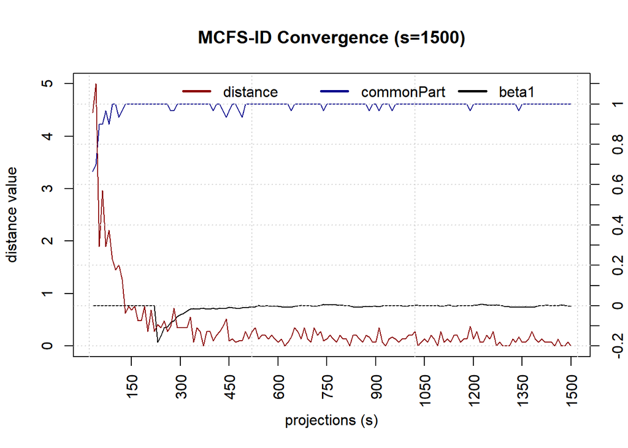

```r
  plot(result, type="distances", legend=TRUE)
```

```r
  result2 <- result$RI[1:result$cutoff_value,]
  result2
```

```
##     position attribute projections classifiers     nodes         RI
## 628        1      P635         142   0.9225352 0.9225352 0.89353275
## 45         2       P48         121   0.9206612 0.9206612 0.89030410
## 200        3      P203         164   0.7695122 0.7695122 0.72116190
## 83         4       P86         132   0.6515151 0.6515151 0.59397155
## 476        5      P483         160   0.6200000 0.6200000 0.55796590
## 703        6      P710         138   0.6115942 0.6115942 0.54995670
## 568        7      P575         165   0.5600000 0.5600000 0.48436427
## 675        8      P682         166   0.5313253 0.5313253 0.45881620
## 464        9      P471         148   0.4391892 0.4391892 0.35621673
## 121       10      P124         157   0.3961783 0.3961783 0.34548670
## 65        11       P68         143   0.3608392 0.3608392 0.28252178
## 685       12      P692         154   0.3376623 0.3376623 0.27878892
## 106       13      P109         150   0.3466667 0.3466667 0.26573600
## 369       14      P375         138   0.3362319 0.3376812 0.26227390
## 662       15      P669         152   0.3144737 0.3144737 0.23166992
## 527       16      P534         151   0.2450331 0.2450331 0.17640005
## 82        17       P85         128   0.2546875 0.2546875 0.15675305
## 454       18      P461         147   0.2299320 0.2299320 0.15583639
## 68        19       P71         153   0.2013072 0.2013072 0.14824481
## 10        20       P13         153   0.2104575 0.2104575 0.12581529
## 272       21      P275         142   0.1732394 0.1732394 0.11266463
## 683       22      P690         150   0.1546667 0.1560000 0.10495973
## 677       23      P684         145   0.1668966 0.1668966 0.09614339
## 614       24      P621         162   0.2111111 0.2111111 0.09205523
## 698       25      P705         158   0.1265823 0.1316456 0.06693651
## 589       26      P596         162   0.1246914 0.1246914 0.06571672
## 293       27      P296         172   0.1139535 0.1151163 0.06007274
```

```r
  # prepare id graph plot
  gid <- build.idgraph(result, size = 20)
```

```
## Selected 16 nodes and 60 edges.
```

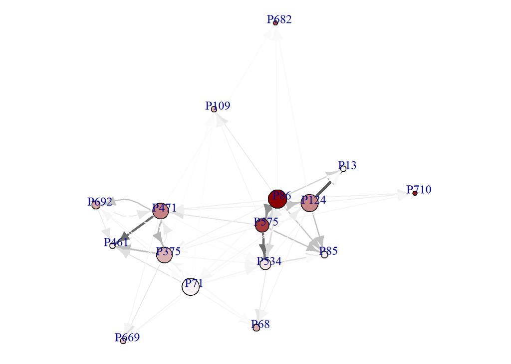

```r
  plot.idgraph(gid, label_dist = 0.5)
```

The graph is an interdependence graph that outlines the interdependence of specific genes (attributes/features) – represented by a node - on one another. The edges show the type of relationship or dependence between the nodes, with the edge color/depth showing the strength of that relationship. Nodes with a lot of influence or dependence can be considered more influential (e.g., P86 in the picture above).

## Rosetta

```r
  # ros <- rosetta(result$data, discrete=T, roc = TRUE, clroc = "Avian")
  #
  # rules <- ros$main
  # kbl(result$data) %>%
  #  kable_styling(bootstrap_options = c("striped", "hover"), full_width = F, position = "center")
  #
  # # rule sets for avian species
  # rlsAv <- viewRules(rules[rules$decision == "Avian", ])
  # rlsAv
  #
  # # rule sets for humans
  # rlsHum <- viewRules(rules[rules$decision == "Human", ])
  # rlsHum
  #
  # # # We can check how much variation there is in amino acids per position/site in the protein
  # # hist(len(sapply(result$data, table)))
```